# 分析文档

## Week 13

自人类迈入蒸汽时代以来迄今为止，获取能源以维持社会经济运转的方式大头始终是依赖燃烧——石油、煤、天然气，因此燃烧能源的消耗很多时候通过大气的碳排放即可推算得来。  
自千禧年以来，西方发达国家一直在号召碳中和计划，矛头直指发展中国家的碳排放巨大，对地球污染造成巨大影响，并且借此机会以通过限制碳排放的公约以间接完成限制他国经济发展水平的目的。

### 数据分析

读取数据

```python
import pandas as pd
import numpy as np
from mpl_toolkits.basemap import Basemap
import shapefile
import matplotlib.pyplot as plt
from matplotlib.patches import Polygon
from matplotlib.colors import rgb2hex
import matplotlib
matplotlib.rcParams['axes.unicode_minus']=False #显示负号
plt.rcParams['font.sans-serif']=['SimHei'] #中文显示
import warnings
warnings.filterwarnings("ignore")
#读取数据
data1 = pd.read_csv(r"historical_emissions.csv")#历史排放数据
data2 = pd.read_csv(r"sources.csv")#数据来源
```

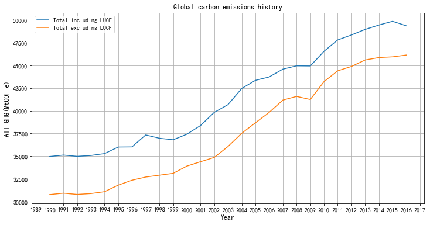

```python
df1 = data1[(data1["Country"]=="World")&(data1["Gas"]=="All GHG")]
x = df1.columns[5:][::-1]
y1 = df1.values[0,5:][::-1]#Total including LUCF
y2 = df1.values[1,5:][::-1]#Total excluding LUCF
plt.figure(figsize=(12,6))
plt.plot(x,y1)
plt.plot(x,y2)
plt.xlabel("Year",fontsize=12)
plt.ylabel("All GHG(MtCO₂e)",fontsize=12)
plt.legend(["Total including LUCF","Total excluding LUCF"])
plt.title("Global carbon emissions history")
plt.grid()
plt.show()
```

根据上述全球历史碳排放量趋势图能够看出，全球碳排放量整体呈现上升趋势；大致可以分为两个阶段，在2000年以前，全球碳排放量呈现缓慢上升趋势，2000年之后呈现加速上升趋势，其中在2008到2009年有一个上升缓冲阶段。

#### 2、最近一年的碳排放全球热度图是怎么样的？

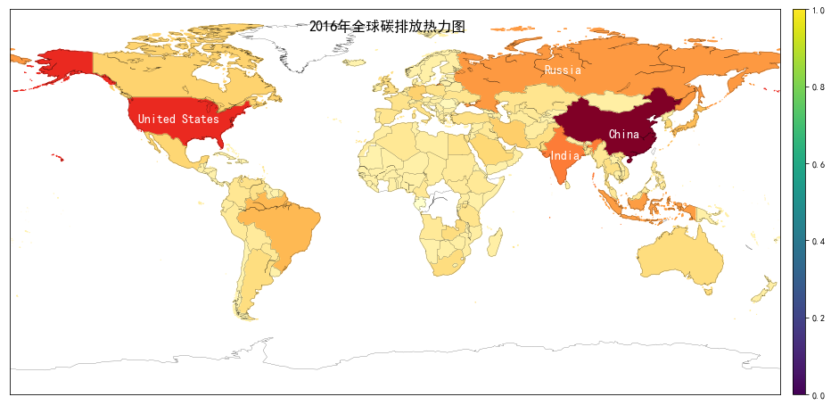

```python
df2 = data1[(data1["Gas"]=="All GHG")&(data1["Sector"]=="Total including LUCF")]
country = df2["Country"].values[1:]
GHG = df2["2016"].values[1:]
G = pd.Series(GHG,index=country)
cmap = plt.cm.YlOrRd
colors = {s:cmap(np.sqrt((G[s]-G.min())/(G.max()-G.min())))[:3] for s in G.index}
plt.figure(figsize=(16,12))
mm = Basemap(projection="cyl",llcrnrx=-180,llcrnry=-90,urcrnrx=180,urcrnry=90)
mm.drawcoastlines(linewidth=0.2)
mm.drawcountries(linewidth=0.2)
mm.readshapefile("ne_50m_admin_0_countries","countries",drawbounds=False,default_encoding="ISO-8859-1")
count = []
for p in mm.countries_info:
    count.append(p["NAME"])
ax = plt.gca()
for c in G.index[:]:
    for name,seg in zip(count,mm.countries):
        if c in name:
            color = rgb2hex(colors[c]) # 将 RGB 色彩转为 HEX 色彩
            poly = Polygon(seg,
                   facecolor=color,
                   edgecolor=color)
            ax.add_patch(poly)
        else:
            pass
plt.text(100,30,"China",fontsize=14,color="w")
plt.text(72,20,"India",fontsize=14,color="w")
plt.text(70,60,"Russia",fontsize=14,color="w")
plt.text(-120,37,"United States",fontsize=14,color="w")
plt.text(-40,80,"2016年全球碳排放热力图",fontsize=16)
mm.colorbar(pad=0.2,size=0.2)
plt.show()
```

根据数据集数据情况，碳排放量最近的记录为2016年，其全球碳排放量热度图如上所示，颜色越深的区域碳排放量越大，其中能够明显的看出，中美两国属于碳排放量前二的国家，亚洲区域内的碳排放量最多，非洲、澳洲和南美洲颜色较浅，碳排放最少。

#### 3、号召降低碳排放的各发达国家，排放量是怎么样的？

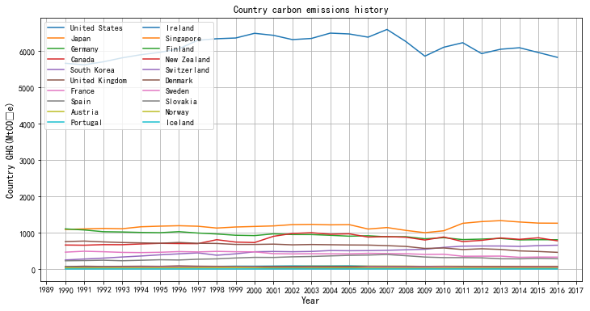

```python
#号召降低碳排放的发达国家列表
countries = ["Austria","United States","Canada","Denmark","Finland","France","Germany","Iceland","Ireland","Japan","New Zealand",\
             "Norway", "Portugal", "Singapore","Slovakia","South Korea","Spain","Sweden","Switzerland","United Kingdom"]
df3 = df2[df2["Country"].isin(countries)]
x = df3.columns[5:][::-1]
plt.figure(figsize=(12,6))
for i in range(len(df3)):
    y = df3.values[i,5:][::-1]#including LUCF
    plt.plot(x,y)
plt.xlabel("Year",fontsize=12)
plt.ylabel("Country GHG(MtCO₂e)",fontsize=12)
plt.legend(df3["Country"],ncol=2,loc="upper left")
plt.title("Country carbon emissions history")
plt.grid()
plt.show()
```

根据上图可以看出，号召降低碳排放的各发达国家，除美国外，大多数国家碳排放量处于较低水平，且波动率较小。

#### 4、碳排放量与该国的经济状况是否有强相关性？

```python
#获取各国国内生产宗旨（GDP_MD）
GDP_MD = []
for c in country:
    for p in mm.countries_info:
        if c in p["NAME"]:
            g = [c,p["GDP_MD"]]
            if g not in GDP_MD:
                GDP_MD.append(g)
GDP_MD = pd.DataFrame(GDP_MD,columns=["Country","GDP_MD"])
GDP_MD = GDP_MD.sort_values("GDP_MD",ascending=False)
GDP_MD = GDP_MD.drop_duplicates("Country",keep="first")
df4 = df2[df2["Country"].isin(GDP_MD["Country"])]
GDP_MD.index = GDP_MD["Country"]
df4.index = df4["Country"]
df4 = pd.concat([GDP_MD,df4],axis=1)[["GDP_MD","2016"]]
#计算碳排放量与该国的GDP的相关性
kendall = df4.corr("kendall").values[0][1]
spearman = df4.corr("spearman").values[0][1]
pearson = df4.corr("pearson").values[0][1]
print("2016年各国碳排放量与GDP的相关性系数：")
print("kendall相关性系数：%s"%kendall)
print("spearman相关性系数：%s"%spearman)
print("pearson相关性系数：%s"%pearson)
```

```
2016年各国碳排放量与GDP的相关性系数：
kendall相关性系数：0.6208385939265068
spearman相关性系数：0.7954082870429956
pearson相关性系数：0.8382275984562655
```

#### 5、每一年发达国家和发展中国家的碳排放量占比变化？

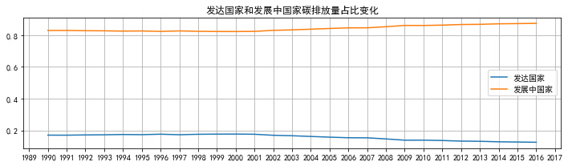

```python
#发达国家列表
country = ["United States","Canada", "Australia", "New Zealand", "United Kingdom", "Ireland", "France","Netherlands",\
           "Belgium", "Luxembourg", "Germany", "Austria", "Switzerland", "Norway", "Iceland", "Denmark", "Sweden", "Finland",\
           "Italy", "Spain","Portugal", "Greece", "Slovenia","Czech Republic", "Slovakia", "Malta", "Cyprus", "Japan",\
           "South Korea", "Singapore", "Israel"]
df5 = df2[df2["Country"].isin(country)].sum()[5:]
Y = df2.sum()[5:]
P1 = df5/Y[::-1]
plt.figure(figsize=(12,3))
plt.plot(P1.index,P1)
plt.plot(P1.index,1-P1)
plt.legend(["发达国家","发展中国家"])
plt.title("发达国家和发展中国家碳排放量占比变化")
plt.grid()
plt.show()
```

根据上图所示，发达国家的碳排放量占比为10%-20%之间，同时在2000年以后，每一年发达国家碳排放占比逐年降低。

#### 6、讨论国家人口与碳排放量之间的关系

```python
#获取各国国内生产宗旨（GDP_MD）
GDP_MD = []
for c in country:
    for p in mm.countries_info:
        if c in p["NAME"]:
            g = [c,p["POP_EST"]]
            if g not in GDP_MD:
                GDP_MD.append(g)
GDP_MD = pd.DataFrame(GDP_MD,columns=["Country","GDP_MD"])
GDP_MD = GDP_MD.sort_values("GDP_MD",ascending=False)
GDP_MD = GDP_MD.drop_duplicates("Country",keep="first")
df6 = df2[df2["Country"].isin(GDP_MD["Country"])]
GDP_MD.index = GDP_MD["Country"]
df6.index = df6["Country"]
df6 = pd.concat([GDP_MD,df6],axis=1)[["GDP_MD","2016"]]
#计算碳排放量与该国的GDP的相关性
kendall = df6.corr("kendall").values[0][1]
spearman = df6.corr("spearman").values[0][1]
pearson = df6.corr("pearson").values[0][1]
print("2016年各国碳排放量与国家人口的相关性系数：")
print("kendall相关性系数：%s"%kendall)
print("spearman相关性系数：%s"%spearman)
print("pearson相关性系数：%s"%pearson)
```

```
2016年各国碳排放量与国家人口的相关性系数：
kendall相关性系数：0.8068965517241379
spearman相关性系数：0.9354838709677419
pearson相关性系数：0.9647234117926287
```